# Exploratory Analysis

James Santarpio and Mardi Elings

2023-11-30

# Data Analytics Term Project

## Project Desription

### Topic:

The effect of drug decriminalization in Oregon on overdose deaths and well-being compared to California and Washington.

### Why it Matters

The study of drug decriminalization and overdose rates in Oregon has potential for significant policy and societal relevance. There are many debates on the benefits and drawbacks that drug use and decriminalization has on potential for policy implications involving economics, public health, criminal justice, and community well-being.

### Research Question and Motivation

What is the effect of drug decriminalization on overdose deaths and well-being? A policy change like Oregon’s can have significant consequences on populations who are most at risk of overdose deaths, economic impacts on health care costs, and overall well-being. Investigating the effects with county level data, we used a difference-in-difference model with fixed effects to assess the impact of the policy change in Oregon. By comparing the outcomes in Oregon before and after the intervention to a control group of Washington and California counties as control groups.

### Description of Data

#### Overdose Mortality by County in the US:

The Overdose Mortality by County in the US is from the CDC Center for Health Statistics for the years 2020-2023. These provisional county-Level drug Overdose death counts are based on death records and is received by the NCHS receives the death records from the state vital registration offices through the Vital Statistics Cooperative Program (VSCP). The provisional counts are reported by the county were the decedent resided, not necessarily where they died.

#### County Well-Being Rankings:

The County Well-Being Rankings are for the years 2014-2023 and is collected by County Health Rankings & Roadmaps CHR&R, a program of the University of Wisconsin Population Health Institute. The health rankings include deaths which include overdose deaths, years of potential life lost, mental health statistics, income, and other health public health rankings.

#### Overdose by Drug:

The Overdose by drug dataset contains information on non-fatal overdose data by state for 2018-2023. Provided by the CDC, DOSE (Drug Overdose Surveillance and Epidemiology) collects health department reports in each state.

Other variables of interest include opioid and stimulant overdoses and the significance of the change from previous months in those overdoses. Violent Crime Data From the FBI crime data reporter database, the number of violent crimes in Oregon.

#### How are they related?

The Well-Being Ranks, Overdose Mortality by County contain county fips codes, county names and year in relation. The Overdose by Drug has a relationship of total non-fatal drug overdoses in each state.

## Data Processing

For the county health rankings data, we originally had years 2014-2023, but after further inspection we found the way overdose deaths were collected for 2014-2015 was significantly different than for the years 2016-2023. We opted to drop those years and due to those data sets not including as many well-being measures.

The data collected was generally in clean condition. Some column name changes were done, and general data manipulation was completed. For example, health rankings came from yearly filet, which had to be merged together. There was generally little missing data. Violent crime and overdose by drugs contained zero missing values. However, a key data set used, health rankings, contained 13 percent N/A values. These appeared generally randomly scatter, and we will assume these are missing at random and will be ignored.

### Findings and Visualizations

Initial findings include general decrease in well being, after 2020 which is likely due to Covid-19. Well-being variables include, mental health days, fair or poor health days, excessive drinking, and income. Additionally, drug overdose deaths have been increasing, especially since 2020. However, it appears that Oregon’s increase may be slower relative to Washington and Oregon after decriminalizing drugs.

We compared the parallel trends of overdose deaths per-capita in all states using stacked kernel density plots. Pre-treatment shows (2016-2020) fairly similar trends, especially in Oregon and Washington. California has the highest proportion of overdoses in all years.

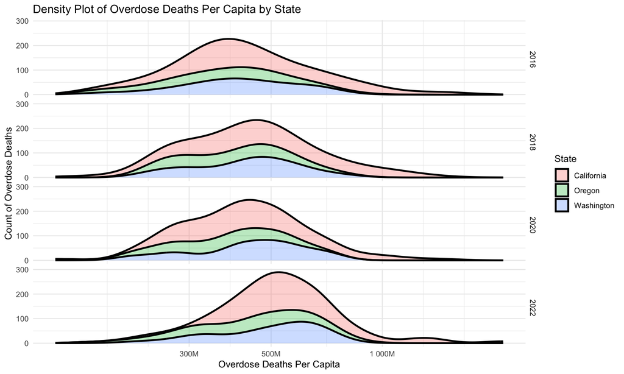

There is an increase in overdose deaths in all states after 2020, which is most likely due to the Covid-19 pandemic. The policy intervention was implemented in Oregon in 2021, and while the drug overdose rates are still increasing, Oregon appears to be increasing at a slightly slower rate than Washington and Oregon.

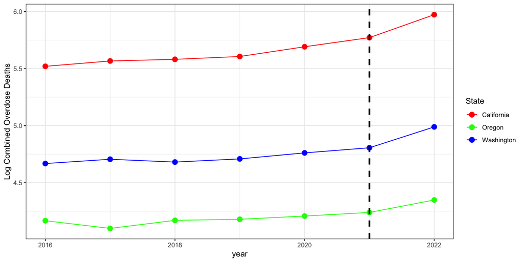

Comparing the rate of drug mortality by county depicts increases after 2020 in many counties with noticeable increases in 2022 for all three states we are examining.

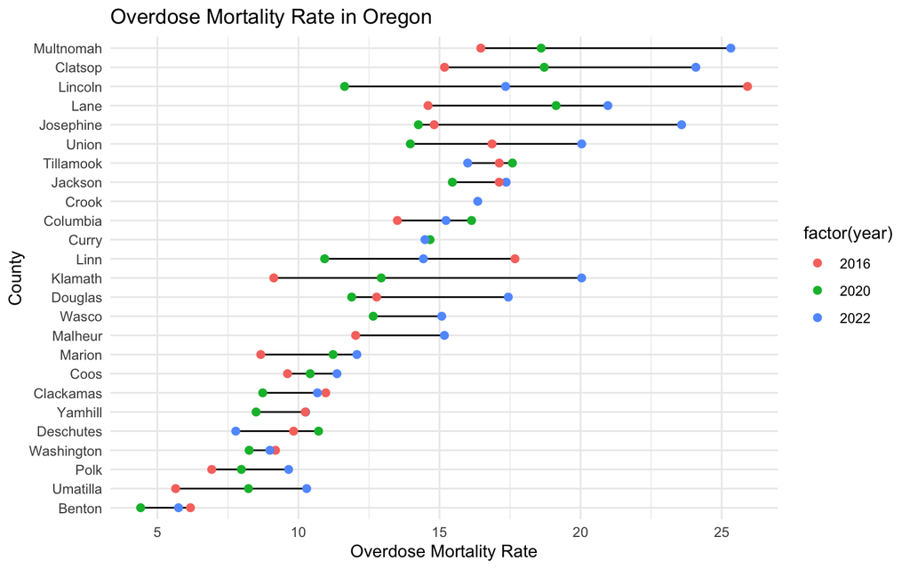

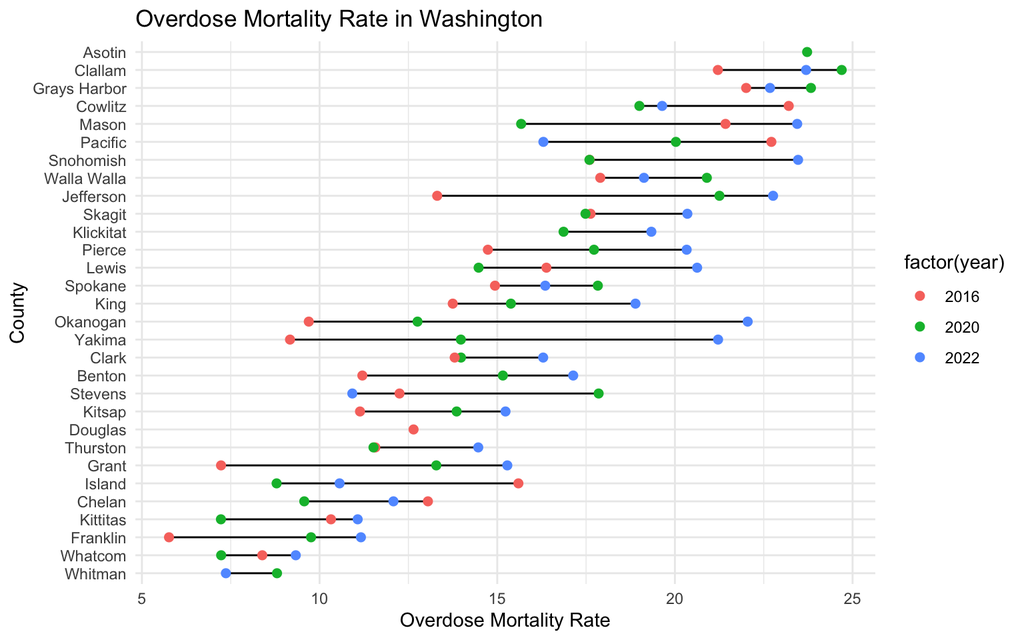

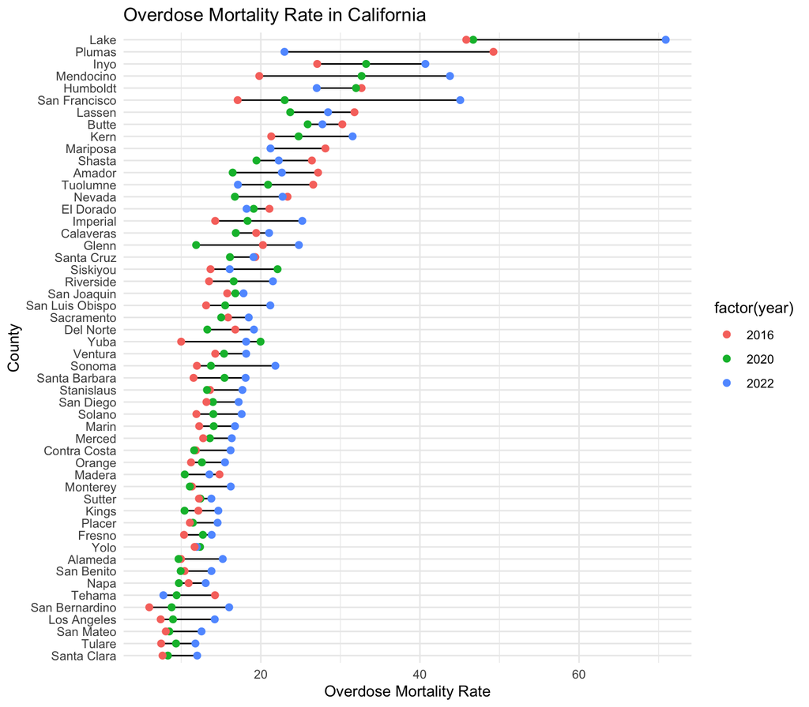

## Methods and Results

### Difference-in-Difference

Regression Coefficients

[output not shown]

### Synthetic Control

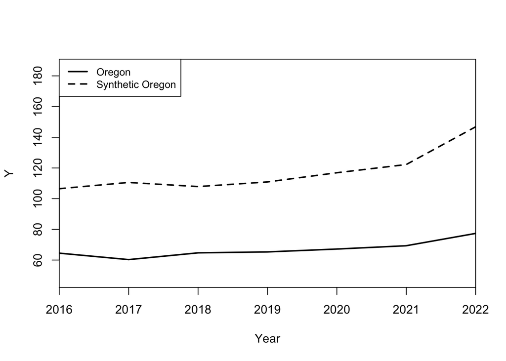

### Limitations

Oregon drug decriminalization has just recently gone into effect. The data for overdose deaths after the law has been enacted is limited with only 2021 and 2022. It is a challenge to find a single cause for an impact on drug decriminalization and its relationship to drug overdose deaths. Since multiple factors can contribute to drug-related outcomes. There has been some evidence linked to the Covid-19 pandemic contributing to drug use, well-being, and mental health.

There is also limited data post treatment period (2 years). Difference-in-Differences (DiD) estimates, particularly with fixed effects, are context-specific and may lack generalizability beyond the studied time period and treatment group.The validity of DiD estimates relies on the assumption of parallel trends in the absence of treatment. While fixed effects enhance internal validity, they may limit generalizability to settings with different characteristics.

Similarly, the synthetic control analysis is specific to the context of Oregon drug policies and may not be generalized to other regions or policies. There is also limited data post treatment period (2 years). Further analysis could be done using all 50 states to find a model that best fits a synthetic Oregon.